# HW2_126

Zejie Gao

2023-02-07

1. This question uses the cereal data set available in the Homework Assignment 2 on Canvas. The following command can be used to read the data into R. Make sure the “cereal.txt” file is in the same folder as your R/Rmd file.

```r
Cereal <- read.table("cereal.txt",header=T)
str(Cereal)
```

```
## 'data.frame':    77 obs. of  16 variables:
##  $ name    : chr  "100%_Bran" "100%_Natural_Bran" "All-Bran" "All-Bran_with_Extra_Fiber" ...
##  $ mfr     : chr  "N" "Q" "K" "K" ...
##  $ type    : chr  "C" "C" "C" "C" ...
##  $ calories: int  70 120 70 50 110 110 110 130 90 90 ...
##  $ protein : int  4 3 4 4 2 2 2 3 2 3 ...
##  $ fat     : int  1 5 1 0 2 2 0 2 1 0 ...
##  $ sodium  : int  130 15 260 140 200 180 125 210 200 210 ...
##  $ fiber   : num  10 2 9 14 1 1.5 1 2 4 5 ...
##  $ carbo   : num  5 8 7 8 14 10.5 11 18 15 13 ...
##  $ sugars  : int  6 8 5 0 8 10 14 8 6 5 ...
##  $ potass  : int  280 135 320 330 -1 70 30 100 125 190 ...
##  $ vitamins: int  25 0 25 25 25 25 25 25 25 25 ...
##  $ shelf   : int  3 3 3 3 3 1 2 3 1 3 ...
##  $ weight  : num  1 1 1 1 1 1 1 1.33 1 1 ...
##  $ cups    : num  0.33 1 0.33 0.5 0.75 0.75 1 0.75 0.67 0.67 ...
##  $ rating  : num  68.4 34 59.4 93.7 34.4 ...
```

```r
Cereal <- as.data.frame(Cereal)
```

1. (4pts) Explore the data and perform a descriptive analysis of each variable, include any plot/statistics that you find relevant (histograms, scatter diagrams, correlation coefficients). Did you find any outlier? If yes, is it reasonable to remove this observation? why?

```r
Cereal <- Cereal|>
  select(name, rating, protein, fat, fiber, carbo, sugars, potass, vitamins, cups)
summary_statistics <- summary(Cereal)
summary_statistics
```

```
##      name               rating         protein           fat
##  Length:77          Min.   :18.04   Min.   :1.000   Min.   :0.000
##  Class :character   1st Qu.:33.17   1st Qu.:2.000   1st Qu.:0.000
##  Mode  :character   Median :40.40   Median :3.000   Median :1.000
##                     Mean   :42.67   Mean   :2.545   Mean   :1.013
##                     3rd Qu.:50.83   3rd Qu.:3.000   3rd Qu.:2.000
##                     Max.   :93.70   Max.   :6.000   Max.   :5.000
##      fiber            carbo          sugars           potass
##  Min.   : 0.000   Min.   :-1.0   Min.   :-1.000   Min.   : -1.00
##  1st Qu.: 1.000   1st Qu.:12.0   1st Qu.: 3.000   1st Qu.: 40.00
##  Median : 2.000   Median :14.0   Median : 7.000   Median : 90.00
##  Mean   : 2.152   Mean   :14.6   Mean   : 6.922   Mean   : 96.08
##  3rd Qu.: 3.000   3rd Qu.:17.0   3rd Qu.:11.000   3rd Qu.:120.00
##  Max.   :14.000   Max.   :23.0   Max.   :15.000   Max.   :330.00
##     vitamins           cups
##  Min.   :  0.00   Min.   :0.250
##  1st Qu.: 25.00   1st Qu.:0.670
##  Median : 25.00   Median :0.750
##  Mean   : 28.25   Mean   :0.821
##  3rd Qu.: 25.00   3rd Qu.:1.000
##  Max.   :100.00   Max.   :1.500
```

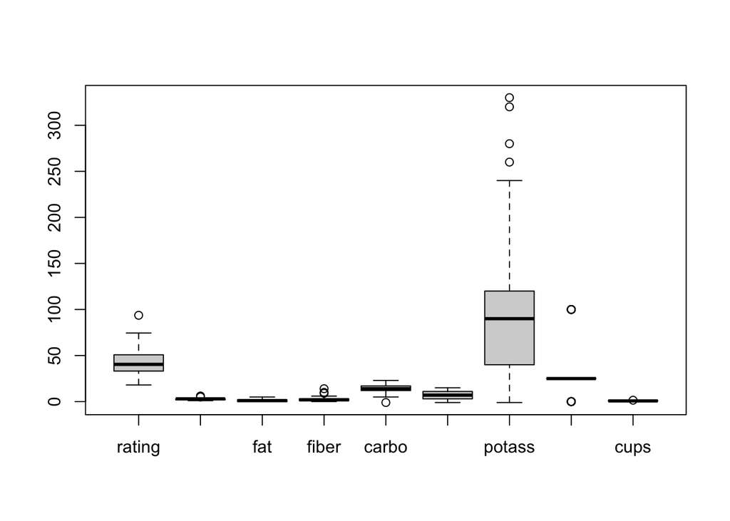

```r
Cereal_num <- Cereal|>
  select(rating, protein, fat, fiber, carbo, sugars, potass, vitamins, cups)
boxplot(Cereal_num)
```

```r
# Based on the minimun of descriptive statistics, summary_statistics, numbers blow 0 in predictors carbo, sugars, and potass are immpossible in the real life. We could consider it as outliers in the varibles' values and remove it for creating a better model.
# In addition, the circles on the boxplot are the outliers that that falls more than 1.5 times the IQR above the upper quartile or below the lower quartile. Except fat and sugar(no outliers on the boxplot), we should check other outliers if it is unreasonable. If it is unreasonable, we should remove the observations.
```

```r
outlier_indices <- function(x){
  boxplot_stats <- boxplot.stats(x)
  outliers <- boxplot_stats$out
  which(x %in% outliers)
}
Cereal[outlier_indices(Cereal$rating),]
```

|  | name | rating | protein | fat | fiber | carbo | sugars | potass | vitamins | cups |
| --- | --- | --- | --- | --- | --- | --- | --- | --- | --- | --- |
| 4 | All-Bran_with_Extra_Fiber | 93.70491 | 4 | 0 | 14 | 8 | 0 | 330 | 25 | 0.5 |

```r
Cereal[outlier_indices(Cereal$protein),]
```

|  | name | rating | protein | fat | fiber | carbo | sugars | potass | vitamins | cups |
| --- | --- | --- | --- | --- | --- | --- | --- | --- | --- | --- |
| 12 | Cheerios | 50.76500 | 6 | 2 | 2.0 | 17 | 1 | 105 | 25 | 1.25 |
| 58 | Quaker_Oatmeal | 50.82839 | 5 | 2 | 2.7 | -1 | -1 | 110 | 0 | 0.67 |
| 68 | Special_K | 53.13132 | 6 | 0 | 1.0 | 16 | 3 | 55 | 25 | 1.00 |

```r
Cereal[outlier_indices(Cereal$fiber),]
```

|  | name | rating | protein | fat | fiber | carbo | sugars | potass | vitamins | cups |
| --- | --- | --- | --- | --- | --- | --- | --- | --- | --- | --- |
| 1 | 100%_Bran | 68.40297 | 4 | 1 | 10 | 5 | 6 | 280 | 25 | 0.33 |
| 3 | All-Bran | 59.42551 | 4 | 1 | 9 | 7 | 5 | 320 | 25 | 0.33 |
| 4 | All-Bran_with_Extra_Fiber | 93.70491 | 4 | 0 | 14 | 8 | 0 | 330 | 25 | 0.50 |

```r
Cereal[outlier_indices(Cereal$carbo),]
```

|  | name | rating | protein | fat | fiber | carbo | sugars | potass | vitamins | cups |
| --- | --- | --- | --- | --- | --- | --- | --- | --- | --- | --- |
| 58 | Quaker_Oatmeal | 50.82839 | 5 | 2 | 2.7 | -1 | -1 | 110 | 0 | 0.67 |

```r
Cereal[outlier_indices(Cereal$potass),]
```

|  | name | rating | protein | fat | fiber | carbo | sugars | potass | vitamins | cups |
| --- | --- | --- | --- | --- | --- | --- | --- | --- | --- | --- |
| 1 | 100%_Bran | 68.40297 | 4 | 1 | 10 | 5 | 6 | 280 | 25 | 0.33 |
| 3 | All-Bran | 59.42551 | 4 | 1 | 9 | 7 | 5 | 320 | 25 | 0.33 |
| 4 | All-Bran_with_Extra_Fiber | 93.70491 | 4 | 0 | 14 | 8 | 0 | 330 | 25 | 0.50 |
| 53 | Post_Nat._Raisin_Bran | 37.84059 | 3 | 1 | 6 | 11 | 14 | 260 | 25 | 0.67 |

```r
Cereal[outlier_indices(Cereal$vitamins),]
```

|  | name | rating | protein | fat | fiber | carbo | sugars | potass | vitamins | cups |
| --- | --- | --- | --- | --- | --- | --- | --- | --- | --- | --- |
| 2 | 100%_Natural_Bran | 33.98368 | 3 | 5 | 2.0 | 8 | 8 | 135 | 0 | 1.00 |
| 21 | Cream_of_Wheat_(Quick) | 64.53382 | 3 | 0 | 1.0 | 21 | 0 | -1 | 0 | 1.00 |
| 39 | Just_Right_Crunchy__Nuggets | 36.52368 | 2 | 1 | 1.0 | 17 | 6 | 60 | 100 | 1.00 |
| 40 | Just_Right_Fruit_&_Nut | 36.47151 | 3 | 1 | 2.0 | 20 | 9 | 95 | 100 | 0.75 |
| 54 | Product_19 | 41.50354 | 3 | 0 | 1.0 | 20 | 3 | 45 | 100 | 1.00 |
| 55 | Puffed_Rice | 60.75611 | 1 | 0 | 0.0 | 13 | 0 | 15 | 0 | 1.00 |
| 56 | Puffed_Wheat | 63.00565 | 2 | 0 | 1.0 | 10 | 0 | 50 | 0 | 1.00 |
| 58 | Quaker_Oatmeal | 50.82839 | 5 | 2 | 2.7 | -1 | -1 | 110 | 0 | 0.67 |
| 64 | Shredded_Wheat | 68.23588 | 2 | 0 | 3.0 | 16 | 0 | 95 | 0 | 1.00 |
| 65 | Shredded_Wheat_'n'Bran | 74.47295 | 3 | 0 | 4.0 | 19 | 0 | 140 | 0 | 0.67 |

[output cut: 4 more lines]

```r
Cereal[outlier_indices(Cereal$cups),]
```

|  | name | rating | protein | fat | fiber | carbo | sugars | potass | vitamins | cups |
| --- | --- | --- | --- | --- | --- | --- | --- | --- | --- | --- |
| 41 | Kix | 39.24111 | 2 | 1 | 0 | 21 | 3 | 40 | 25 | 1.5 |

```r
# outliers in rating is reasonable since 93.70491   does not exceed 100.Other outliers above seems reasonable because the different brand of cereal may contain different content of protein or fiber and so on. Take 100%_Bran as an example, it is a bread contain high fiber. Thus, we should not remove this outliers.
```